# Predictive Machine Learning Assignment

Yuhanis Yusoff

December 27, 2015

# Title: Predictive Meachine Learning - Human Recognition movement

# Background

Using devices such as Jawbone Up, Nike FuelBand, and Fitbit it is now possible to collect a large amount of data about personal activity relatively inexpensively. These type of devices are part of the quantified self movement - a group of enthusiasts who take measurements about themselves regularly to improve their health, to find patterns in their behavior, or because they are tech geeks.

One thing that people regularly do is quantify how much of a particular activity they do, but they rarely quantify how well they do it. In this project, your goal will be to use data from accelerometers on the belt, forearm, arm, and dumbell of 6 participants.

They were asked to perform barbell lifts correctly and incorrectly in 5 different ways. More information is available from the website here: http://groupware.les.inf.puc-rio.br/har (see the section on the Weight Lifting Exercise Dataset).

# Data

The training data for this project are available here: https://d396qusza40orc.cloudfront.net/predmachlearn/pml-training.csv

The test data are available here: https://d396qusza40orc.cloudfront.net/predmachlearn/pml-testing.csv

The data for this project come from this source: http://groupware.les.inf.puc-rio.br/har. If you use the document you create for this class for any purpose please cite them as they have been very generous in allowing their data to be used for this kind of assignment.

# GOAL

The goal of this project is to predict the manner in which they did the exercise. This is the “classe” variable in the training set. You may use any of the other variables to predict with. You should create a report describing how you built your model, how you used cross validation, what you think the expected out of sample error is, and why you made the choices you did. You will also use your prediction model to predict 20 different test cases.

# Data Analysis

```r
library(caret)
library(randomForest) #Random forest for classification and regression
```

```r
library(rpart) #Regressive Partitioning and Regression trees
library(rpart.plot) # Decision Tree plot
# setting the overall seed for reproduceability
set.seed(8881)
```

Load the data sets into R and do some data cleaning

- Missing values are coded correctly.
- Irrelevant variables will be deleted.

```r
setwd("C:/Users/Yuhanis/Documents/My Course/Data Science/e-ClassModule/Course8-PracticalMachineLearning/Assignment")
# Loading the training data set into my R session replacing all missing with "NA"
trainingset <- read.csv("Data/pml-training.csv", na.strings=c("NA","#DIV/0!", ""))

# Loading the testing data set into my R session replacing all missing with "NA"
testingset <- read.csv("Data/pml-testing.csv", na.strings=c("NA","#DIV/0!", ""))

# Check dimensions for number of variables and number of observations
dim(trainingset)
```

```
## [1] 19622   160
```

```r
dim(testingset)
```

```
## [1]  20 160
```

```r
# Delete columns with all missing values
trainingset<-trainingset[,colSums(is.na(trainingset)) == 0]
testingset <-testingset[,colSums(is.na(testingset)) == 0]

# Delete irrelevant variables.
trainingset   <-trainingset[,-c(1:7)]
testingset <-testingset[,-c(1:7)]

# Check the new dimensions for number of variables and number of observations
dim(trainingset)
```

```
## [1] 19622    53
```

```r
dim(testingset)
```

```
## [1] 20 53
```

Now, perform cross-validation, the training data set is partionned into 2 sets: subTraining (75%) and subTest (25%).

```r
subsamples <- createDataPartition(y=trainingset$classe, p=0.75, list=FALSE)
subTraining <- trainingset[subsamples, ]
subTesting <- trainingset[-subsamples, ]
```

The **variable “classe”** contains 5 levels: A, B, C, D and E. A plot of the outcome variable will allow us to see the frequency of each levels in the subTraining data set and compare one another.

- exactly according to the specification (Class A)
- throwing the elbows to the front (Class B)
- lifting the dumbbell only halfway (Class C)
- lowering the dumbbell only halfway (Class D)
- throwing the hips to the front (Class E)

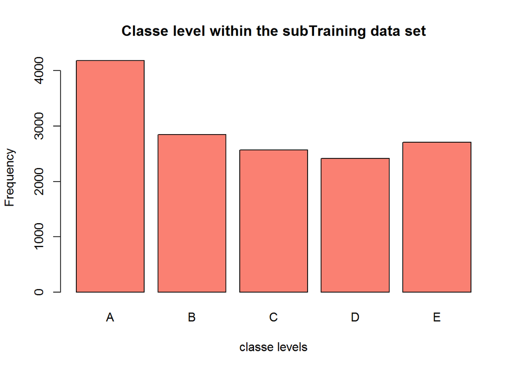

```r
plot(subTraining$classe, col="salmon", main="Classe level within the subTraining data set", xlab="classe levels", ylab="Frequency")
```

From the graph above, Level A is the most frequent with more than 4000 occurrences while level D is the least frequent with about 2500 occurrences.

Now, **First prediction model: Using Decision Tree**

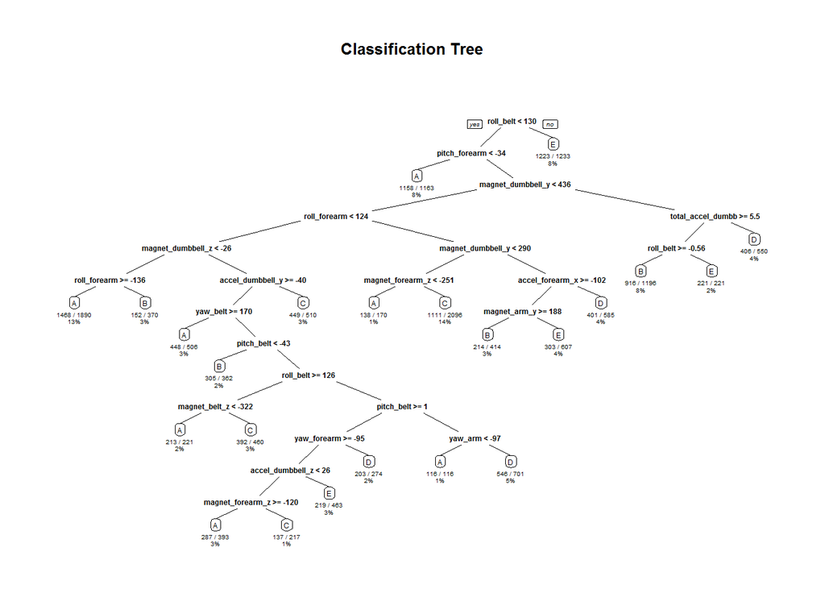

```r
model1 <- rpart(classe ~ ., data=subTraining, method="class")

# Predicting:
prediction1 <- predict(model1, subTesting, type = "class")

# Plot of the Decision Tree
rpart.plot(model1, main="Classification Tree", extra=102, under=TRUE, faclen=0)
```

```r
# Test results on our subTesting data set:
confusionMatrix(prediction1, subTesting$classe)
```

```
## Confusion Matrix and Statistics
##
##           Reference
## Prediction    A    B    C    D    E
##          A 1271  143   21   56   18
##          B   44  510   64   80   64
##          C   41  133  680  114  117
##          D   12   68   70  495   48
##          E   27   95   20   59  654
##
## Overall Statistics
##
##                Accuracy : 0.7361
##                  95% CI : (0.7236, 0.7484)
##     No Information Rate : 0.2845
##     P-Value [Acc > NIR] : < 2.2e-16
##
##                   Kappa : 0.6654
##  Mcnemar's Test P-Value : < 2.2e-16
##
## Statistics by Class:
##
##                      Class: A Class: B Class: C Class: D Class: E
## Sensitivity            0.9111   0.5374   0.7953   0.6157   0.7259
## Specificity            0.9322   0.9363   0.9000   0.9517   0.9498
## Pos Pred Value         0.8423   0.6693   0.6267   0.7143   0.7649
## Neg Pred Value         0.9635   0.8940   0.9542   0.9266   0.9390
## Prevalence             0.2845   0.1935   0.1743   0.1639   0.1837
## Detection Rate         0.2592   0.1040   0.1387   0.1009   0.1334
## Detection Prevalence   0.3077   0.1554   0.2212   0.1413   0.1743
## Balanced Accuracy      0.9216   0.7368   0.8476   0.7837   0.8378
```

**Second prediction model: Using Random Forest**

```r
model2 <- randomForest(classe ~. , data=subTraining, method="class")

# Predicting:
prediction2 <- predict(model2, subTesting, type = "class")

# Test results on subTesting data set:
confusionMatrix(prediction2, subTesting$classe)
```

```
## Confusion Matrix and Statistics
##
##           Reference
## Prediction    A    B    C    D    E
##          A 1394    1    0    0    0
##          B    1  947    5    0    0
##          C    0    1  850    7    4
##          D    0    0    0  797    2
##          E    0    0    0    0  895
##
## Overall Statistics
##
##                Accuracy : 0.9957
##                  95% CI : (0.9935, 0.9973)
##     No Information Rate : 0.2845
##     P-Value [Acc > NIR] : < 2.2e-16
##
##                   Kappa : 0.9946
##  Mcnemar's Test P-Value : NA
##
## Statistics by Class:
##
##                      Class: A Class: B Class: C Class: D Class: E
## Sensitivity            0.9993   0.9979   0.9942   0.9913   0.9933
## Specificity            0.9997   0.9985   0.9970   0.9995   1.0000
## Pos Pred Value         0.9993   0.9937   0.9861   0.9975   1.0000
## Neg Pred Value         0.9997   0.9995   0.9988   0.9983   0.9985
## Prevalence             0.2845   0.1935   0.1743   0.1639   0.1837
## Detection Rate         0.2843   0.1931   0.1733   0.1625   0.1825
## Detection Prevalence   0.2845   0.1943   0.1758   0.1629   0.1825
## Balanced Accuracy      0.9995   0.9982   0.9956   0.9954   0.9967
```

# Result

**Random Forest model is choosen**

1. The accuracy of the model is 0.995.
2. The expected out-of-sample error is estimated at 0.005, or 0.5%.  
   The expected out-of-sample error is calculated as 1 - accuracy for predictions made against the cross-validation set.

Our Test data set comprises 20 cases. With an accuracy above 99% on our cross-validation data, we can expect that very few, or none, of the test samples will be missclassified.

# Submission

```r
# Perform the prediction levels on the original Testing data set by using Random Forest algorithm
predictfinal <- predict(model2, testingset, type="class")
predictfinal
```

```
##  1  2  3  4  5  6  7  8  9 10 11 12 13 14 15 16 17 18 19 20
##  B  A  B  A  A  E  D  B  A  A  B  C  B  A  E  E  A  B  B  B
## Levels: A B C D E
```

```r
# Write files for submission
pml_write_files = function(x){
  n = length(x)
  for(i in 1:n){
    filename = paste0("problem_id_",i,".txt")
    write.table(x[i],file=filename,quote=FALSE,row.names=FALSE,col.names=FALSE)
  }
}

pml_write_files(predictfinal)
```